# Práctica 2: Limpieza y análisis de datos

## 1. Descripción del dataset. ¿Por qué es importante y qué pregunta/problema pretende responder?

Este set de datos contiene diferentes precios de venta con respecto al tipo de casas en EE. UU, Hay 80 variables que dan la propiedad de la casa y la variable predicha está en el último precio de venta de esta

La variable 'SalePrice' es la variable a predecir dentro de este conjunto de datos. Mas adelante se realizar una predicción al valor de esta variable después del debido análisis exploratorio, por lo cual es la que se va a estudiar con mayor detenimiento

https://www.kaggle.com/gpandi007/usa-housing-dataset

# 2. Integración y selección de los datos de interés a analizar

- SalesPrice: el precio de venta de la propiedad en dólares. Esta es la variable objetivo que está tratando de predecir.
- MSSubClass: la clase de construcción
- MSZoning: la clasificación general de zonificación
- LotFrontage: pies lineales de calle conectados a la propiedad
- LotArea: Tamaño del lote en pies cuadrados
- Calle: Tipo de acceso por carretera
- Callejón: Tipo de acceso al callejón
- LotShape: forma general de la propiedad
- LandContour: Planitud de la propiedad
- Utilidades: tipo de utilidades disponibles
- LotConfig: configuración del lote
- LandSlope: Pendiente de la propiedad
- Vecindario: ubicaciones físicas dentro de los límites de la ciudad de Ames
- Condition1: Proximidad a la carretera principal o al ferrocarril
- Condición 2: Proximidad a la carretera principal o al ferrocarril (si hay un segundo)
- BldgType: Tipo de vivienda
- HouseStyle: estilo de vivienda
- OverallQual: Material general y calidad de acabado.
- OverallCond: Calificación de estado general
- Año de construcción: fecha de construcción original
- YearRemodAdd: fecha de remodelación
- RoofStyle: Tipo de techo
- RoofMatl: material del techo
- Exterior1st: Revestimiento exterior de la casa
- Exterior2nd: Revestimiento exterior de la casa (si hay más de un material)
- MasVnrType: tipo de chapa de mampostería
- MasVnrArea: Área de revestimiento de mampostería en pies cuadrados
- ExterQual: Calidad del material exterior
- ExterCond: Estado actual del material en el exterior
- Fundación: Tipo de fundación
- BsmtQual: Altura del sótano
- BsmtCond: Estado general del sótano
- BsmtExposure: Paredes de sótano a nivel de jardín o de salida
- BsmtFinType1: Calidad del área terminada del sótano
- BsmtFinSF1: pies cuadrados terminados tipo 1
- BsmtFinType2: Calidad de la segunda área terminada (si está presente)
- BsmtFinSF2: pies cuadrados con acabado tipo 2
- BsmtUnfSF: pies cuadrados sin terminar de área del sótano
- TotalBsmtSF: Total de pies cuadrados de área del sótano
- Calefacción: Tipo de calefacción
- Calefacción QC: calidad y estado de la calefacción
- CentralAir: aire acondicionado central
- Eléctrico: sistema eléctrico
- 1stFlrSF: pies cuadrados del primer piso
- 2ndFlrSF: pies cuadrados del segundo piso
- LowQualFinSF: pies cuadrados con acabado de baja calidad (todos los pisos)
- GrLivArea: pies cuadrados de área habitable sobre el nivel (suelo)
- BsmtFullBath: Baños completos en el sótano
- BsmtHalfBath: Medios baños del sótano
- FullBath: baños completos sobre rasante
- HalfBath: Medios baños sobre el nivel del suelo
- Dormitorio: número de dormitorios sobre el nivel del sótano
- Cocina: Número de cocinas
- KitchenQual: calidad de la cocina
- TotRmsAbvGrd: Total de habitaciones sobre rasante (no incluye baños)
- Funcional: clasificación de funcionalidad del hogar
- Chimeneas: Número de chimeneas
- FireplaceQu: Calidad de chimenea
- GarageType: Ubicación del garaje
- GarageYrBlt: año en que se construyó el garaje
- GarageFinish: Acabado interior del garaje
- GarageCars: Tamaño del garaje en capacidad de automóvil
- GarageArea: Tamaño del garaje en pies cuadrados
- GarageQual: Calidad de garaje
- GarageCond: Estado del garaje
- PavedDrive: entrada pavimentada
- WoodDeckSF: Área de la plataforma de madera en pies cuadrados
- OpenPorchSF: Área de porche abierto en pies cuadrados
- Porche cerrado: área de porche cerrado en pies cuadrados
- 3SsnPorch: área de porche de tres estaciones en pies cuadrados
- ScreenPorch: Área del porche de la pantalla en pies cuadrados
- PoolArea: Área de la piscina en pies cuadrados
- PoolQC: Calidad de la piscina
- Valla: calidad de la valla
- MiscFeature: característica miscelánea no cubierta en otras categorías
- MiscVal: $ Valor de la función miscelánea
- MoSold: Mes vendido
- YrSold: año vendido
- SaleType: Tipo de venta
- SaleCondition: Condición de venta

# 3. Limpieza de los datos.

### 3.1. ¿Los datos contienen ceros o elementos vacíos? ¿Cómo gestionarías cada uno de estos casos?

```python
import pandas as pd
import numpy as np
import matplotlib.pyplot as plt
from matplotlib import style
import seaborn as sns
from scipy import stats
import warnings
warnings.filterwarnings("ignore")
```

```python
df_train = pd.read_csv("housing_train.csv")
```

```python
df_train.head()
```

|  | Id | MSSubClass | MSZoning | LotFrontage | LotArea | Street | Alley | LotShape | LandContour | Utilities | LotConfig | LandSlope | Neighborhood | Condition1 | Condition2 | BldgType | HouseStyle | OverallQual | OverallCond | YearBuilt | YearRemodAdd | RoofStyle | RoofMatl | Exterior1st | Exterior2nd | MasVnrType | MasVnrArea | ExterQual | ExterCond | … |
| --- | --- | --- | --- | --- | --- | --- | --- | --- | --- | --- | --- | --- | --- | --- | --- | --- | --- | --- | --- | --- | --- | --- | --- | --- | --- | --- | --- | --- | --- | --- |
| 0 | 1 | 60 | RL | 65.0 | 8450 | Pave | NaN | Reg | Lvl | AllPub | Inside | Gtl | CollgCr | Norm | Norm | 1Fam | 2Story | 7 | 5 | 2003 | 2003 | Gable | CompShg | VinylSd | VinylSd | BrkFace | 196.0 | Gd | TA | … |
| 1 | 2 | 20 | RL | 80.0 | 9600 | Pave | NaN | Reg | Lvl | AllPub | FR2 | Gtl | Veenker | Feedr | Norm | 1Fam | 1Story | 6 | 8 | 1976 | 1976 | Gable | CompShg | MetalSd | MetalSd | None | 0.0 | TA | TA | … |
| 2 | 3 | 60 | RL | 68.0 | 11250 | Pave | NaN | IR1 | Lvl | AllPub | Inside | Gtl | CollgCr | Norm | Norm | 1Fam | 2Story | 7 | 5 | 2001 | 2002 | Gable | CompShg | VinylSd | VinylSd | BrkFace | 162.0 | Gd | TA | … |
| 3 | 4 | 70 | RL | 60.0 | 9550 | Pave | NaN | IR1 | Lvl | AllPub | Corner | Gtl | Crawfor | Norm | Norm | 1Fam | 2Story | 7 | 5 | 1915 | 1970 | Gable | CompShg | Wd Sdng | Wd Shng | None | 0.0 | TA | TA | … |
| 4 | 5 | 60 | RL | 84.0 | 14260 | Pave | NaN | IR1 | Lvl | AllPub | FR2 | Gtl | NoRidge | Norm | Norm | 1Fam | 2Story | 8 | 5 | 2000 | 2000 | Gable | CompShg | VinylSd | VinylSd | BrkFace | 350.0 | Gd | TA | … |

5 rows × 81 columns

```python
df_train.drop(['Id'], axis = 1, inplace = True)
```

#### Evaluación de datos faltantes

Los valores faltantes se convierten al valor predeterminado de Python. Utilizamos las funciones integradas de Python para identificar estos valores faltantes. Hay dos métodos para detectar datos faltantes:

- .isnull()
- .notnull()

La salida es un valor booleano que indica si el valor que se pasa al argumento es de hecho datos faltantes.

```python
missing_data = df_train.isnull()
```

"Verdadero" significa valor perdido, mientras que "Falso" significa valor no perdido

```python
missing_data.head()
```

[output not shown]

#### Cantidad de valores faltantes por columna

```python
total = df_train.isnull().sum().sort_values(ascending = False)
percent = (df_train.isnull().sum() / df_train.isnull().count()).sort_values(ascending = False)
missing_data = pd.concat([total, percent], axis = 1, keys = ['Total', 'Percent'])
missing_data[missing_data['Total'] > 0]
```

|  | Total | Percent |
| --- | --- | --- |
| PoolQC | 1453 | 0.995205 |
| MiscFeature | 1406 | 0.963014 |
| Alley | 1369 | 0.937671 |
| Fence | 1179 | 0.807534 |
| FireplaceQu | 690 | 0.472603 |
| LotFrontage | 259 | 0.177397 |
| GarageCond | 81 | 0.055479 |
| GarageType | 81 | 0.055479 |
| GarageYrBlt | 81 | 0.055479 |
| GarageFinish | 81 | 0.055479 |
| GarageQual | 81 | 0.055479 |
| BsmtExposure | 38 | 0.026027 |
| BsmtFinType2 | 38 | 0.026027 |
| BsmtFinType1 | 37 | 0.025342 |
| BsmtCond | 37 | 0.025342 |
| BsmtQual | 37 | 0.025342 |
| MasVnrArea | 8 | 0.005479 |
| MasVnrType | 8 | 0.005479 |
| Electrical | 1 | 0.000685 |

[figure not shown]

```python
sns.heatmap(df_train.isnull(), yticklabels=False, cbar = False, cmap = "Blues");
```

#### Según el resumen anterior, cada columna tiene 1460 filas de datos, 19 columnas que contienen datos faltantes:

1. LotFrontage. 259 datos faltantes
2. Alley. 1369 datos faltantes
3. MasVnrType. 8 datos faltantes
4. MasVnrArea. 8 datos faltantes
5. BsmtQual. 37 datos faltantes
6. BsmtCond. 37 datos faltantes
7. BsmtExposure. 38 datos faltantes
8. BsmtFinType1. 37 datos faltantes
9. BsmtFinType2. 38 datos faltantes
10. Electrical. 1 dato faltantes
11. FireplaceQu. 690 datos faltantes
12. GarageType. 81 datos faltantes
13. GarageYrBlt. 81 datos faltantes
14. GarageFinish. 81 datos faltantes
15. GarageQual. 81 datos faltantes
16. GarageCond. 81 datos faltantes
17. PoolQC. 1453 datos faltantes
18. Fence. 1179 datos faltantes
19. MiscFeature. 1406 datos faltantes

#### ¿Cómo lidiar con los datos faltantes?

1. Eliminar datos  
   a. Eliminar toda la fila  
   b. Eliminar toda la columna
2. reemplazar datos  
   a. Reemplazar por la media  
   b. Reemplazar por la frecuencia  
   c. Reemplazar en función de otras funciones

#### Nuestro data set de housing_train tiene 1460 filas, las columnas solo deben descartarse si la mayoría de las entradas de la columna están vacías. , En este caso serian.

1. Alley. 1369 datos faltantes
2. PoolQC. 1453 datos faltantes
3. Fence. 1179 datos faltantes
4. MiscFeature. 1406 datos faltantes

```python
df_train = df_train.drop(['Alley', 'PoolQC', 'Fence', 'MiscFeature'], axis=1)
```

#### Reemplazo por el Promedio

```python
avg_LotFrontage = df_train['LotFrontage'].astype('float').mean(axis=0)
df_train['LotFrontage'].replace(np.nan, avg_LotFrontage, inplace=True)

avg_MasVnrArea = df_train['MasVnrArea'].astype('float').mean(axis=0)
df_train['MasVnrArea'].replace(np.nan, avg_MasVnrArea, inplace=True)

avg_GarageYrBlt = df_train['GarageYrBlt'].astype('float').mean(axis=0)
df_train['GarageYrBlt'].replace(np.nan, avg_MasVnrArea, inplace=True)
```

#### Reemplazo por la frecuencia

```python
max_MasVnrType = df_train["MasVnrType"].value_counts().idxmax()
df_train["MasVnrType"].replace(np.nan, max_MasVnrType, inplace=True)

max_BsmtQual = df_train["BsmtQual"].value_counts().idxmax()
df_train["BsmtQual"].replace(np.nan, max_BsmtQual, inplace=True)

max_BsmtCond = df_train["BsmtCond"].value_counts().idxmax()
df_train["BsmtQual"].replace(np.nan, max_BsmtCond, inplace=True)

max_BsmtExposure = df_train["BsmtExposure"].value_counts().idxmax()
df_train["BsmtExposure"].replace(np.nan, max_BsmtExposure, inplace=True)

max_BsmtFinType1 = df_train["BsmtFinType1"].value_counts().idxmax()
df_train["BsmtFinType1"].replace(np.nan, max_BsmtFinType1, inplace=True)

max_BsmtFinType2 = df_train["BsmtFinType2"].value_counts().idxmax()
df_train["BsmtFinType2"].replace(np.nan, max_BsmtFinType2, inplace=True)

max_Electrical = df_train["Electrical"].value_counts().idxmax()
df_train["Electrical"].replace(np.nan, max_Electrical, inplace=True)

max_FireplaceQu = df_train["FireplaceQu"].value_counts().idxmax()
df_train["FireplaceQu"].replace(np.nan, max_FireplaceQu, inplace=True)

max_GarageType = df_train["GarageType"].value_counts().idxmax()
df_train["GarageType"].replace(np.nan, max_FireplaceQu, inplace=True)

max_GarageFinish = df_train["GarageFinish"].value_counts().idxmax()
df_train["GarageFinish"].replace(np.nan, max_GarageFinish, inplace=True)

max_GarageQual = df_train["GarageQual"].value_counts().idxmax()
df_train["GarageQual"].replace(np.nan, max_GarageQual, inplace=True)

max_GarageCond = df_train["GarageCond"].value_counts().idxmax()
df_train["GarageCond"].replace(np.nan, max_GarageCond, inplace=True)

max_BsmtCond = df_train["BsmtCond"].value_counts().idxmax()
df_train["BsmtCond"].replace(np.nan, max_BsmtCond, inplace=True)
```

#### Comprobamos si existen valores faltantes

```python
total = df_train.isnull().sum().sort_values(ascending = False)
percent = (df_train.isnull().sum() / df_train.isnull().count()).sort_values(ascending = False)
missing_data = pd.concat([total, percent], axis = 1, keys = ['Total', 'Percent'])
missing_data[missing_data['Total'] > 0]
```

|  | Total | Percent |
| --- | --- | --- |

[figure not shown]

```python
sns.heatmap(df_train.isnull(), yticklabels=False, cbar = False, cmap = "Blues");
```

### 3.2. Identificación y tratamiento de valores extremos.

#### Datos atípicos

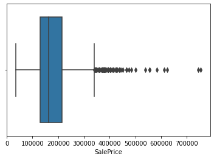

```python
ax = sns.boxplot(x=df_train['SalePrice'])
```

Los puntos que se encuentran fuera de los bigotes son los Outlier

```python
df_train['SalePrice'].describe()
```

```
count      1460.000000
mean     180921.195890
std       79442.502883
min       34900.000000
25%      129975.000000
50%      163000.000000
75%      214000.000000
max      755000.000000
Name: SalePrice, dtype: float64
```

```python
Q1 = df_train['SalePrice'].quantile(0.25)
Q3 = df_train['SalePrice'].quantile(0.75)
IQR = Q3 - Q1
IQR
```

```
84025.0
```

**Calculo de los valores del bigote superior e inferior**

```python
BI_Calculado = (Q1 - 1.5 * IQR)
BI_Calculado
```

```
3937.5
```

```python
BS_Calculado = (Q3 + 1.5 * IQR)
BS_Calculado
```

```
340037.5
```

**Ubicación de los datos atípicos**

```python
ubicacion_outlier = (df_train['SalePrice'] < BI_Calculado) | (df_train['SalePrice'] > BS_Calculado)
```

```python
outlier= pd.DataFrame(df_train[ubicacion_outlier]['SalePrice'])
```

```python
outlier.size
```

```
61
```

Podemos ver existen 61 elementos que son datos atípicos

Y estos elementos se los podría tratar de diferentes formas:

- **Eliminación de los datos de valores atípicos :** omite los valores de valores atípicos.
- **Capa de los datos de valores atípicos :** se reemplazan los valores de valores atípicos con el límite superior y el límite inferior. los valores atípicos que se encuentran en un límite superior se reemplazarán por valores de límite superior. De lo contrario, los valores atípicos que se encuentran más en el límite inferior se pueden reemplazar por un límite inferior.
- **Reemplazo por nuevos valores :** Reemplaza el valor de los valores atípicos con la media, la mediana o la moda.

# 4. Análisis de los datos.

### 4.1. Selección de los grupos de datos que se quieren analizar/comparar.

- Mi variable objetivo es SALEPRICE
- LotShape: forma general de la propiedad
- MSZoning: la clasificación general de zonificación

```python
df_train.head()
```

[output not shown]

### 4.2. Comprobación de la normalidad y homogeneidad de la varianza.

#### Análisis univariante de la variable SalePrice

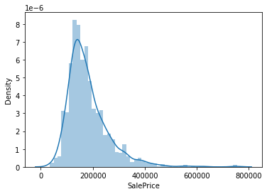

```python
sns.distplot(df_train['SalePrice'])
plt.show()
```

```python
df_train['SalePrice'].skew()
```

```
1.8828757597682129
```

Como vemos la función sesgo nos da un valor mayor a cero con lo cual nos indica que existe una asimetría positiva en esta distribución

```python
df_train['SalePrice'].kurt()
```

```
6.536281860064529
```

La curtosis es una medida estadística que determina el grado de concentración que presentan los valores de una variable alrededor de la zona central de la distribución de frecuencias. También es conocida como medida de apuntamiento.

Tipos de curtosis

- Leptocúrtica: Existe una gran concentración de los valores en torno a su media
- Mesocúrtica: Existe una concentración normal de los valores en torno a su media
- Platicúrtica: Existe una baja concentración de los valores en torno a su media

Vemos que la función curtosis nos da un valor mayor a 3 con lo cual inferimos que se trata de una distribución Leptocúrtica

#### Prueba de normalidad

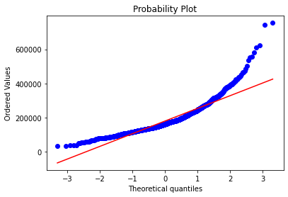

```python
import scipy.stats as stats
import pylab
stats.probplot(df_train['SalePrice'], dist="norm", plot=pylab)
pylab.show()
```

La prueba shapiro-wilk es una prueba de normalidad. Se utiliza para determinar si una muestra procede o no de una distribución normal. Para realizar una prueba de Shapiro-Wilk en Python podemos utilizar la función scipy.stats.shapiro()

Esta función devuelve una estadística de prueba y un valor p correspondiente. Si el valor p está por debajo de un cierto nivel de significancia, entonces tenemos suficiente evidencia para decir que los datos de la muestra no provienen de una distribución normal.

```python
from scipy.stats import shapiro
```

```python
shapiro(df_train['SalePrice'])
```

```
(0.869671642780304, 3.206247534576162e-33)
```

##### Homogeneidad de la varianza

El supuesto de homogeneidad de varianzas, también conocido como supuesto de homocedasticidad, considera que la varianza es constante (no varía) en los diferentes niveles de un factor, es decir, entre diferentes grupos. En los modelos de regresión lineal, esta condición de homocedasticidad suele hacer referencia a los errores (residuos) del modelo, es decir, que la varianza de los errores es constante en todas las predicciones. Cuando la condición de homocedasticidad no se cumple, se utiliza el término heterocedasticidad.

##### Métodos gráficos

Dos de los métodos gráficos más empleados para el análisis homocedasticidad consiste en representar los datos mediante un boxplot o un violinplot. Con ambos gráficos el objetivo es comparar la dispersión de los grupos.

#### Contraste de hipótesis

El test de Levene, el test de Bartlett y el test de Fligner-Killeen son tres de los test de hipótesis más empleados comparar la varianza entre grupos. En todos ellos, se considera como hipótesis nula que los datos proceden de distribuciones con la misma varianza (homocedasticidad). Por lo tanto, si el p-value es menor que un determinado valor (típicamente 0.05), entonces se considera que hay evidencias suficientes para rechazar la homocedasticidad en favor de la heterocedasticidad.

El test de Levene y el test de Fligner-Killeen (este último no paramétrico) son más robustos que el test de Bartlett ante la falta de normalidad, por lo que suele aconsejarse su uso. Además, tanto el test de Levene como el de Bartlett permiten elegir entre diferentes estadísticos de centralidad: mediana (por defecto), media, media truncada. Esto es importante a la hora de contrastar la homocedasticidad dependiendo de si los grupos se distribuyen de forma normal o no.

Si se tiene seguridad de que las muestras a comparar proceden de poblaciones que siguen una distribución normal, es recomendable el test de Bartlett. Si no se tiene la seguridad de que las poblaciones de origen son normales, se recomiendan el test de Leven utilizando la mediana o el test no paramétrico Fligner-Killeen que también se basa en la mediana.

##### LotShape - SalePrice

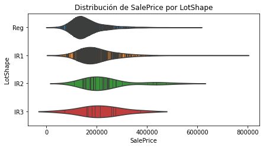

```python
# Grafico violinplot
# ==============================================================================
fig, ax = plt.subplots(nrows=1, ncols=1, figsize=(7, 3.5))
sns.violinplot(
    x       = 'SalePrice',
    y       = 'LotShape',
    data    = df_train,
    palette = 'tab10',
    inner   = 'stick',
    ax      = ax
)
ax.set_title('Distribución de SalePrice por LotShape')
plt.show()
```

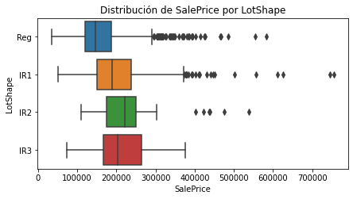

```python
# Grafico boxplot
# ==============================================================================
fig, ax = plt.subplots(nrows=1, ncols=1, figsize=(7, 3.5))
sns.boxplot(
    x       = 'SalePrice',
    y       = 'LotShape',
    data    = df_train,
    palette = 'tab10',
    ax      = ax
)
ax.set_title('Distribución de SalePrice por LotShape')
plt.show()
```

```python
df_train.groupby('LotShape')['LotShape'].count()
```

```
LotShape
IR1    484
IR2     41
IR3     10
Reg    925
Name: LotShape, dtype: int64
```

```python
Reg = df_train.loc[df_train['LotShape']=='Reg', 'SalePrice']
IR1 = df_train.loc[df_train['LotShape']=='IR1', 'SalePrice']
IR2 = df_train.loc[df_train['LotShape']=='IR2', 'SalePrice']
IR3 = df_train.loc[df_train['LotShape']=='IR3', 'SalePrice']
```

##### Levene test

```python
levene_test = stats.levene(Reg, IR1, center='median')
levene_test
```

```
LeveneResult(statistic=10.02945769702319, pvalue=0.001573642610874719)
```

```python
levene_test = stats.levene(Reg, IR2, center='median')
levene_test
```

```
LeveneResult(statistic=5.248104635704628, pvalue=0.022185757561315005)
```

```python
levene_test = stats.levene(Reg, IR3, center='median')
levene_test
```

```
LeveneResult(statistic=0.671306703587738, pvalue=0.41280564044159695)
```

```python
levene_test = stats.levene(IR1, IR2, center='median')
levene_test
```

```
LeveneResult(statistic=0.8237942649407701, pvalue=0.3644911512590411)
```

```python
levene_test = stats.levene(IR1, IR3, center='median')
levene_test
```

```
LeveneResult(statistic=0.031905469541259855, pvalue=0.8583088135689912)
```

```python
levene_test = stats.levene(IR2, IR3, center='median')
levene_test
```

```
LeveneResult(statistic=0.0581727973482552, pvalue=0.8104139996454308)
```

##### Bartlett test

```python
bartlett_test = stats.bartlett(Reg, IR1)
bartlett_test
```

```
BartlettResult(statistic=28.70513162022838, pvalue=8.428010651862852e-08)
```

```python
bartlett_test = stats.bartlett(Reg, IR2)
bartlett_test
```

```
BartlettResult(statistic=12.227352383355683, pvalue=0.0004709397930255049)
```

```python
bartlett_test = stats.bartlett(Reg, IR3)
bartlett_test
```

```
BartlettResult(statistic=0.5531228135531009, pvalue=0.45704451419258085)
```

```python
bartlett_test = stats.bartlett(IR1, IR2)
bartlett_test
```

```
BartlettResult(statistic=1.7743998830108587, pvalue=0.18283849489626766)
```

```python
bartlett_test = stats.bartlett(IR1, IR3)
bartlett_test
```

```
BartlettResult(statistic=0.025811321275066728, pvalue=0.8723619659764233)
```

```python
bartlett_test = stats.bartlett(IR2, IR3)
bartlett_test
```

```
BartlettResult(statistic=0.46389141859975536, pvalue=0.4958109070687946)
```

##### Fligner test

```python
fligner_test = stats.fligner(Reg, IR1, center='median')
fligner_test
```

```
FlignerResult(statistic=13.766613730098925, pvalue=0.00020698209041753967)
```

```python
fligner_test = stats.fligner(Reg, IR2, center='median')
fligner_test
```

```
FlignerResult(statistic=4.881495130375992, pvalue=0.027146095495459963)
```

```python
fligner_test = stats.fligner(Reg, IR3, center='median')
fligner_test
```

```
FlignerResult(statistic=1.385719254216643, pvalue=0.23912934741234135)
```

```python
fligner_test = stats.fligner(IR1, IR2, center='median')
fligner_test
```

```
FlignerResult(statistic=0.5517919764030405, pvalue=0.45758641662762467)
```

```python
fligner_test = stats.fligner(IR1, IR3, center='median')
fligner_test
```

```
FlignerResult(statistic=0.19474673930114694, pvalue=0.6589949655523909)
```

```python
fligner_test = stats.fligner(IR2, IR3, center='median')
fligner_test
```

```
FlignerResult(statistic=0.00455343373290176, pvalue=0.9462002715894207)
```

Después de ver los resultados de los tres test vemos que en los únicos casos donde no hay homocedasticidad de la varianza es el caso de REG – IR1 y REG – IR2 dado que su p-valor es menor a 0.05

##### MSZoning - SalePrice

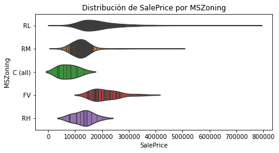

```python
# Grafico violinplot
# ==============================================================================
fig, ax = plt.subplots(nrows=1, ncols=1, figsize=(7, 3.5))
sns.violinplot(
    x       = 'SalePrice',
    y       = 'MSZoning',
    data    = df_train,
    palette = 'tab10',
    inner   = 'stick',
    ax      = ax
)
ax.set_title('Distribución de SalePrice por MSZoning')
plt.show()
```

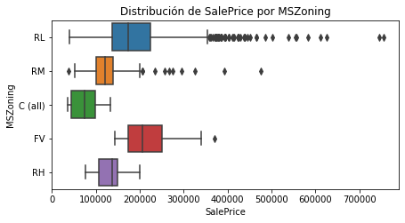

```python
# Grafico boxplot
# ==============================================================================
fig, ax = plt.subplots(nrows=1, ncols=1, figsize=(7, 3.5))
sns.boxplot(
    x       = 'SalePrice',
    y       = 'MSZoning',
    data    = df_train,
    palette = 'tab10',
    ax      = ax
)
ax.set_title('Distribución de SalePrice por MSZoning')
plt.show()
```

```python
df_train.groupby('MSZoning')['MSZoning'].count()
```

```
MSZoning
C (all)      10
FV           65
RH           16
RL         1151
RM          218
Name: MSZoning, dtype: int64
```

```python
C_ALL = df_train.loc[df_train['MSZoning']=='C (all)', 'SalePrice']
FV = df_train.loc[df_train['MSZoning']=='FV', 'SalePrice']
RH = df_train.loc[df_train['MSZoning']=='RH', 'SalePrice']
RL = df_train.loc[df_train['MSZoning']=='RL', 'SalePrice']
RM = df_train.loc[df_train['MSZoning']=='RM', 'SalePrice']
```

##### Levene test

```python
levene_test = stats.levene(C_ALL, FV, center='median')
levene_test
```

```
LeveneResult(statistic=1.5873688427180535, pvalue=0.21171544528504524)
```

```python
levene_test = stats.levene(C_ALL, RH, center='median')
levene_test
```

```
LeveneResult(statistic=0.00028802373980012236, pvalue=0.986599842791283)
```

```python
levene_test = stats.levene(C_ALL, RL, center='median')
levene_test
```

```
LeveneResult(statistic=2.183683578676473, pvalue=0.13975195881654912)
```

```python
levene_test = stats.levene(C_ALL, RM, center='median')
levene_test
```

```
LeveneResult(statistic=0.007489747944098886, pvalue=0.9311111390963048)
```

```python
levene_test = stats.levene(FV, RH, center='median')
levene_test
```

```
LeveneResult(statistic=2.3458586312324847, pvalue=0.12961121663597802)
```

```python
levene_test = stats.levene(FV, RL, center='median')
levene_test
```

```
LeveneResult(statistic=3.838370003608285, pvalue=0.050320797774997345)
```

```python
levene_test = stats.levene(FV, RM, center='median')
levene_test
```

```
LeveneResult(statistic=5.300027652423261, pvalue=0.022056219079350438)
```

```python
levene_test = stats.levene(RH, RL, center='median')
levene_test
```

```
LeveneResult(statistic=3.4561221508235107, pvalue=0.06326993801137373)
```

```python
levene_test = stats.levene(RH, RM, center='median')
levene_test
```

```
LeveneResult(statistic=0.009005111534511376, pvalue=0.9244799267991024)
```

```python
levene_test = stats.levene(RL, RM, center='median')
levene_test
```

```
LeveneResult(statistic=40.793810833861386, pvalue=2.3133355102232034e-10)
```

##### Bartlett test

```python
bartlett_test = stats.bartlett(C_ALL, FV)
bartlett_test
```

```
BartlettResult(statistic=2.346382997023141, pvalue=0.1255740717332625)
```

```python
bartlett_test = stats.bartlett(C_ALL, RH)
bartlett_test
```

```
BartlettResult(statistic=0.032651085969455006, pvalue=0.8566061083866217)
```

```python
bartlett_test = stats.bartlett(C_ALL, RL)
bartlett_test
```

```
BartlettResult(statistic=7.941873966646063, pvalue=0.004830378697822398)
```

```python
bartlett_test = stats.bartlett(C_ALL, RM)
bartlett_test
```

```
BartlettResult(statistic=1.76392516352663, pvalue=0.18413567827156027)
```

```python
bartlett_test = stats.bartlett(FV, RH)
bartlett_test
```

```
BartlettResult(statistic=2.953597354099913, pvalue=0.08568662766591219)
```

```python
bartlett_test = stats.bartlett(FV, RL)
bartlett_test
```

```
BartlettResult(statistic=17.6907626748585, pvalue=2.5988559536693613e-05)
```

```python
bartlett_test = stats.bartlett(FV, RM)
bartlett_test
```

```
BartlettResult(statistic=0.588301480785226, pvalue=0.44307667817530016)
```

```python
bartlett_test = stats.bartlett(RH, RL)
bartlett_test
```

```
BartlettResult(statistic=12.081952327958444, pvalue=0.0005091225653413434)
```

```python
bartlett_test = stats.bartlett(RH, RM)
bartlett_test
```

```
BartlettResult(statistic=2.168089785201384, pvalue=0.14090116062246077)
```

```python
bartlett_test = stats.bartlett(RL, RM)
bartlett_test
```

```
BartlettResult(statistic=74.79611933786141, pvalue=5.219219582113103e-18)
```

##### Fligner test

```python
fligner_test = stats.fligner(C_ALL, FV, center='median')
fligner_test
```

```
FlignerResult(statistic=1.575897202243228, pvalue=0.20935265958348925)
```

```python
fligner_test = stats.fligner(C_ALL, RH, center='median')
fligner_test
```

```
FlignerResult(statistic=0.00920849775086978, pvalue=0.9235516123205795)
```

```python
fligner_test = stats.fligner(C_ALL, RL, center='median')
fligner_test
```

```
FlignerResult(statistic=3.0691526895173, pvalue=0.07979104974747335)
```

```python
fligner_test = stats.fligner(C_ALL, RM, center='median')
fligner_test
```

```
FlignerResult(statistic=0.2940220635357066, pvalue=0.5876545511283112)
```

```python
fligner_test = stats.fligner(FV, RH, center='median')
fligner_test
```

```
FlignerResult(statistic=1.6853420514246225, pvalue=0.19421612914413133)
```

```python
fligner_test = stats.fligner(FV, RL, center='median')
fligner_test
```

```
FlignerResult(statistic=3.7535119598856985, pvalue=0.052696681001369455)
```

```python
fligner_test = stats.fligner(FV, RM, center='median')
fligner_test
```

```
FlignerResult(statistic=15.924916220207596, pvalue=6.59053831267048e-05)
```

```python
fligner_test = stats.fligner(RH, RL, center='median')
fligner_test
```

```
FlignerResult(statistic=4.785419114430117, pvalue=0.02870166219144856)
```

```python
fligner_test = stats.fligner(RH, RM, center='median')
fligner_test
```

```
FlignerResult(statistic=0.3215389218214851, pvalue=0.5706842737995116)
```

```python
fligner_test = stats.fligner(RL, RM, center='median')
fligner_test
```

```
FlignerResult(statistic=70.58732588869948, pvalue=4.403369151889778e-17)
```

### 4.2. Aplicación de pruebas estadísticas

#### Matriz de correlación (en forma de mapa de calor)

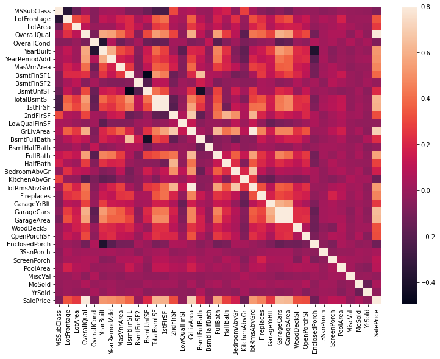

```python
correlations = df_train.corr()
f, ax = plt.subplots(figsize = (12, 9))
sns.heatmap(correlations, vmax=.8, annot = False)
plt.show()
```

EL mapa de calor muestra las correlaciones entre las variables, vemos que la diagonal esta altamente relacionada y esto es lógico todas las variables están correlacionadas consigo misma, entre más claro este un recuadro donde coinciden dos variables significa que hay una fuerte correlación positiva, y entre mas oscuro indica que hay una correlación a la inversa

```python
var_num = df_train._get_numeric_data().columns.values.tolist()
```

```python
df_train[var_num].corr()
```

|  | MSSubClass | LotFrontage | LotArea | OverallQual | OverallCond | YearBuilt | YearRemodAdd | MasVnrArea | BsmtFinSF1 | BsmtFinSF2 | BsmtUnfSF | TotalBsmtSF | 1stFlrSF | 2ndFlrSF | LowQualFinSF | GrLivArea | BsmtFullBath | BsmtHalfBath | FullBath | HalfBath | BedroomAbvGr | KitchenAbvGr | TotRmsAbvGrd | Fireplaces | GarageYrBlt | GarageCars | GarageArea | WoodDeckSF | OpenPorchSF | … |
| --- | --- | --- | --- | --- | --- | --- | --- | --- | --- | --- | --- | --- | --- | --- | --- | --- | --- | --- | --- | --- | --- | --- | --- | --- | --- | --- | --- | --- | --- | --- |
| MSSubClass | 1.000000 | -0.357056 | -0.139781 | 0.032628 | -0.059316 | 0.027850 | 0.040581 | 0.022895 | -0.069836 | -0.065649 | -0.140759 | -0.238518 | -0.251758 | 0.307886 | 0.046474 | 0.074853 | 0.003491 | -0.002333 | 0.131608 | 0.177354 | -0.023438 | 0.281721 | 0.040380 | -0.045569 | -0.080750 | -0.040110 | -0.098672 | -0.012579 | -0.006100 | … |
| LotFrontage | -0.357056 | 1.000000 | 0.306795 | 0.234196 | -0.052820 | 0.117598 | 0.082746 | 0.179283 | 0.215828 | 0.043340 | 0.122156 | 0.363358 | 0.414266 | 0.072483 | 0.036849 | 0.368392 | 0.091481 | -0.006419 | 0.180424 | 0.048258 | 0.237023 | -0.005805 | 0.320146 | 0.235755 | 0.100432 | 0.269729 | 0.323663 | 0.077106 | 0.137454 | … |
| LotArea | -0.139781 | 0.306795 | 1.000000 | 0.105806 | -0.005636 | 0.014228 | 0.013788 | 0.103960 | 0.214103 | 0.111170 | -0.002618 | 0.260833 | 0.299475 | 0.050986 | 0.004779 | 0.263116 | 0.158155 | 0.048046 | 0.126031 | 0.014259 | 0.119690 | -0.017784 | 0.190015 | 0.271364 | 0.072515 | 0.154871 | 0.180403 | 0.171698 | 0.084774 | … |
| OverallQual | 0.032628 | 0.234196 | 0.105806 | 1.000000 | -0.091932 | 0.572323 | 0.550684 | 0.410238 | 0.239666 | -0.059119 | 0.308159 | 0.537808 | 0.476224 | 0.295493 | -0.030429 | 0.593007 | 0.111098 | -0.040150 | 0.550600 | 0.273458 | 0.101676 | -0.183882 | 0.427452 | 0.396765 | 0.290467 | 0.600671 | 0.562022 | 0.238923 | 0.308819 | … |
| OverallCond | -0.059316 | -0.052820 | -0.005636 | -0.091932 | 1.000000 | -0.375983 | 0.073741 | -0.127788 | -0.046231 | 0.040229 | -0.136841 | -0.171098 | -0.144203 | 0.028942 | 0.025494 | -0.079686 | -0.054942 | 0.117821 | -0.194149 | -0.060769 | 0.012980 | -0.087001 | -0.057583 | -0.023820 | -0.007410 | -0.185758 | -0.151521 | -0.003334 | -0.032589 | … |
| YearBuilt | 0.027850 | 0.117598 | 0.014228 | 0.572323 | -0.375983 | 1.000000 | 0.592855 | 0.314745 | 0.249503 | -0.049107 | 0.149040 | 0.391452 | 0.281986 | 0.010308 | -0.183784 | 0.199010 | 0.187599 | -0.038162 | 0.468271 | 0.242656 | -0.070651 | -0.174800 | 0.095589 | 0.147716 | 0.274269 | 0.537850 | 0.478954 | 0.224880 | 0.188686 | … |
| YearRemodAdd | 0.040581 | 0.082746 | 0.013788 | 0.550684 | 0.073741 | 0.592855 | 1.000000 | 0.179186 | 0.128451 | -0.067759 | 0.181133 | 0.291066 | 0.240379 | 0.140024 | -0.062419 | 0.287389 | 0.119470 | -0.012337 | 0.439046 | 0.183331 | -0.040581 | -0.149598 | 0.191740 | 0.112581 | 0.148142 | 0.420622 | 0.371600 | 0.205726 | 0.226298 | … |
| MasVnrArea | 0.022895 | 0.179283 | 0.103960 | 0.410238 | -0.127788 | 0.314745 | 0.179186 | 1.000000 | 0.263582 | -0.072302 | 0.114184 | 0.362452 | 0.342160 | 0.174019 | -0.069068 | 0.389893 | 0.085055 | 0.026669 | 0.275730 | 0.200802 | 0.102417 | -0.037364 | 0.280027 | 0.247906 | 0.134442 | 0.363778 | 0.372567 | 0.159349 | 0.124965 | … |
| BsmtFinSF1 | -0.069836 | 0.215828 | 0.214103 | 0.239666 | -0.046231 | 0.249503 | 0.128451 | 0.263582 | 1.000000 | -0.050117 | -0.495251 | 0.522396 | 0.445863 | -0.137079 | -0.064503 | 0.208171 | 0.649212 | 0.067418 | 0.058543 | 0.004262 | -0.107355 | -0.081007 | 0.044316 | 0.260011 | 0.116264 | 0.224054 | 0.296970 | 0.204306 | 0.111761 | … |
| BsmtFinSF2 | -0.065649 | 0.043340 | 0.111170 | -0.059119 | 0.040229 | -0.049107 | -0.067759 | -0.072302 | -0.050117 | 1.000000 | -0.209294 | 0.104810 | 0.097117 | -0.099260 | 0.014807 | -0.009640 | 0.158678 | 0.070948 | -0.076444 | -0.032148 | -0.015728 | -0.040751 | -0.035227 | 0.046921 | 0.034810 | -0.038264 | -0.018227 | 0.067898 | 0.003093 | … |
| BsmtUnfSF | -0.140759 | 0.122156 | -0.002618 | 0.308159 | -0.136841 | 0.149040 | 0.181133 | 0.114184 | -0.495251 | -0.209294 | 1.000000 | 0.415360 | 0.317987 | 0.004469 | 0.028167 | 0.240257 | -0.422900 | -0.095804 | 0.288886 | -0.041118 | 0.166643 | 0.030086 | 0.250647 | 0.051575 | 0.043257 | 0.214175 | 0.183303 | -0.005316 | 0.129005 | … |
| TotalBsmtSF | -0.238518 | 0.363358 | 0.260833 | 0.537808 | -0.171098 | 0.391452 | 0.291066 | 0.362452 | 0.522396 | 0.104810 | 0.415360 | 1.000000 | 0.819530 | -0.174512 | -0.033245 | 0.454868 | 0.307351 | -0.000315 | 0.323722 | -0.048804 | 0.050450 | -0.068901 | 0.285573 | 0.339519 | 0.177242 | 0.434585 | 0.486665 | 0.232019 | 0.247264 | … |
| 1stFlrSF | -0.251758 | 0.414266 | 0.299475 | 0.476224 | -0.144203 | 0.281986 | 0.240379 | 0.342160 | 0.445863 | 0.097117 | 0.317987 | 0.819530 | 1.000000 | -0.202646 | -0.014241 | 0.566024 | 0.244671 | 0.001956 | 0.380637 | -0.119916 | 0.127401 | 0.068101 | 0.409516 | 0.410531 | 0.167279 | 0.439317 | 0.489782 | 0.235459 | 0.211671 | … |
| 2ndFlrSF | 0.307886 | 0.072483 | 0.050986 | 0.295493 | 0.028942 | 0.010308 | 0.140024 | 0.174019 | -0.137079 | -0.099260 | 0.004469 | -0.174512 | -0.202646 | 1.000000 | 0.063353 | 0.687501 | -0.169494 | -0.023855 | 0.421378 | 0.609707 | 0.502901 | 0.059306 | 0.616423 | 0.194561 | 0.064594 | 0.183926 | 0.138347 | 0.092165 | 0.208026 | … |
| LowQualFinSF | 0.046474 | 0.036849 | 0.004779 | -0.030429 | 0.025494 | -0.183784 | -0.062419 | -0.069068 | -0.064503 | 0.014807 | 0.028167 | -0.033245 | -0.014241 | 0.063353 | 1.000000 | 0.134683 | -0.047143 | -0.005842 | -0.000710 | -0.027080 | 0.105607 | 0.007522 | 0.131185 | -0.021272 | -0.146529 | -0.094480 | -0.067601 | -0.025444 | 0.018251 | … |
| GrLivArea | 0.074853 | 0.368392 | 0.263116 | 0.593007 | -0.079686 | 0.199010 | 0.287389 | 0.389893 | 0.208171 | -0.009640 | 0.240257 | 0.454868 | 0.566024 | 0.687501 | 0.134683 | 1.000000 | 0.034836 | -0.018918 | 0.630012 | 0.415772 | 0.521270 | 0.100063 | 0.825489 | 0.461679 | 0.163166 | 0.467247 | 0.468997 | 0.247433 | 0.330224 | … |
| BsmtFullBath | 0.003491 | 0.091481 | 0.158155 | 0.111098 | -0.054942 | 0.187599 | 0.119470 | 0.085055 | 0.649212 | 0.158678 | -0.422900 | 0.307351 | 0.244671 | -0.169494 | -0.047143 | 0.034836 | 1.000000 | -0.147871 | -0.064512 | -0.030905 | -0.150673 | -0.041503 | -0.053275 | 0.137928 | 0.049612 | 0.131881 | 0.179189 | 0.175315 | 0.067341 | … |
| BsmtHalfBath | -0.002333 | -0.006419 | 0.048046 | -0.040150 | 0.117821 | -0.038162 | -0.012337 | 0.026669 | 0.067418 | 0.070948 | -0.095804 | -0.000315 | 0.001956 | -0.023855 | -0.005842 | -0.018918 | -0.147871 | 1.000000 | -0.054536 | -0.012340 | 0.046519 | -0.037944 | -0.023836 | 0.028976 | 0.016589 | -0.020891 | -0.024536 | 0.040161 | -0.025324 | … |
| FullBath | 0.131608 | 0.180424 | 0.126031 | 0.550600 | -0.194149 | 0.468271 | 0.439046 | 0.275730 | 0.058543 | -0.076444 | 0.288886 | 0.323722 | 0.380637 | 0.421378 | -0.000710 | 0.630012 | -0.064512 | -0.054536 | 1.000000 | 0.136381 | 0.363252 | 0.133115 | 0.554784 | 0.243671 | 0.138812 | 0.469672 | 0.405656 | 0.187703 | 0.259977 | … |
| HalfBath | 0.177354 | 0.048258 | 0.014259 | 0.273458 | -0.060769 | 0.242656 | 0.183331 | 0.200802 | 0.004262 | -0.032148 | -0.041118 | -0.048804 | -0.119916 | 0.609707 | -0.027080 | 0.415772 | -0.030905 | -0.012340 | 0.136381 | 1.000000 | 0.226651 | -0.068263 | 0.343415 | 0.203649 | 0.117706 | 0.219178 | 0.163549 | 0.108080 | 0.199740 | … |
| BedroomAbvGr | -0.023438 | 0.237023 | 0.119690 | 0.101676 | 0.012980 | -0.070651 | -0.040581 | 0.102417 | -0.107355 | -0.015728 | 0.166643 | 0.050450 | 0.127401 | 0.502901 | 0.105607 | 0.521270 | -0.150673 | 0.046519 | 0.363252 | 0.226651 | 1.000000 | 0.198597 | 0.676620 | 0.107570 | -0.010024 | 0.086106 | 0.065253 | 0.046854 | 0.093810 | … |
| KitchenAbvGr | 0.281721 | -0.005805 | -0.017784 | -0.183882 | -0.087001 | -0.174800 | -0.149598 | -0.037364 | -0.081007 | -0.040751 | 0.030086 | -0.068901 | 0.068101 | 0.059306 | 0.007522 | 0.100063 | -0.041503 | -0.037944 | 0.133115 | -0.068263 | 0.198597 | 1.000000 | 0.256045 | -0.123936 | -0.158281 | -0.050634 | -0.064433 | -0.090130 | -0.070091 | … |
| TotRmsAbvGrd | 0.040380 | 0.320146 | 0.190015 | 0.427452 | -0.057583 | 0.095589 | 0.191740 | 0.280027 | 0.044316 | -0.035227 | 0.250647 | 0.285573 | 0.409516 | 0.616423 | 0.131185 | 0.825489 | -0.053275 | -0.023836 | 0.554784 | 0.343415 | 0.676620 | 0.256045 | 1.000000 | 0.326114 | 0.096004 | 0.362289 | 0.337822 | 0.165984 | 0.234192 | … |
| Fireplaces | -0.045569 | 0.235755 | 0.271364 | 0.396765 | -0.023820 | 0.147716 | 0.112581 | 0.247906 | 0.260011 | 0.046921 | 0.051575 | 0.339519 | 0.410531 | 0.194561 | -0.021272 | 0.461679 | 0.137928 | 0.028976 | 0.243671 | 0.203649 | 0.107570 | -0.123936 | 0.326114 | 1.000000 | 0.186368 | 0.300789 | 0.269141 | 0.200019 | 0.169405 | … |
| GarageYrBlt | -0.080750 | 0.100432 | 0.072515 | 0.290467 | -0.007410 | 0.274269 | 0.148142 | 0.134442 | 0.116264 | 0.034810 | 0.043257 | 0.177242 | 0.167279 | 0.064594 | -0.146529 | 0.163166 | 0.049612 | 0.016589 | 0.138812 | 0.117706 | -0.010024 | -0.158281 | 0.096004 | 0.186368 | 1.000000 | 0.599321 | 0.562087 | 0.117931 | 0.050508 | … |
| GarageCars | -0.040110 | 0.269729 | 0.154871 | 0.600671 | -0.185758 | 0.537850 | 0.420622 | 0.363778 | 0.224054 | -0.038264 | 0.214175 | 0.434585 | 0.439317 | 0.183926 | -0.094480 | 0.467247 | 0.131881 | -0.020891 | 0.469672 | 0.219178 | 0.086106 | -0.050634 | 0.362289 | 0.300789 | 0.599321 | 1.000000 | 0.882475 | 0.226342 | 0.213569 | … |
| GarageArea | -0.098672 | 0.323663 | 0.180403 | 0.562022 | -0.151521 | 0.478954 | 0.371600 | 0.372567 | 0.296970 | -0.018227 | 0.183303 | 0.486665 | 0.489782 | 0.138347 | -0.067601 | 0.468997 | 0.179189 | -0.024536 | 0.405656 | 0.163549 | 0.065253 | -0.064433 | 0.337822 | 0.269141 | 0.562087 | 0.882475 | 1.000000 | 0.224666 | 0.241435 | … |
| WoodDeckSF | -0.012579 | 0.077106 | 0.171698 | 0.238923 | -0.003334 | 0.224880 | 0.205726 | 0.159349 | 0.204306 | 0.067898 | -0.005316 | 0.232019 | 0.235459 | 0.092165 | -0.025444 | 0.247433 | 0.175315 | 0.040161 | 0.187703 | 0.108080 | 0.046854 | -0.090130 | 0.165984 | 0.200019 | 0.117931 | 0.226342 | 0.224666 | 1.000000 | 0.058661 | … |
| OpenPorchSF | -0.006100 | 0.137454 | 0.084774 | 0.308819 | -0.032589 | 0.188686 | 0.226298 | 0.124965 | 0.111761 | 0.003093 | 0.129005 | 0.247264 | 0.211671 | 0.208026 | 0.018251 | 0.330224 | 0.067341 | -0.025324 | 0.259977 | 0.199740 | 0.093810 | -0.070091 | 0.234192 | 0.169405 | 0.050508 | 0.213569 | 0.241435 | 0.058661 | 1.000000 | … |
| EnclosedPorch | -0.012037 | 0.009790 | -0.018340 | -0.113937 | 0.070356 | -0.387268 | -0.193919 | -0.109849 | -0.102303 | 0.036543 | -0.002538 | -0.095478 | -0.065292 | 0.061989 | 0.061081 | 0.009113 | -0.049911 | -0.008555 | -0.115093 | -0.095317 | 0.041570 | 0.037312 | 0.004151 | -0.024822 | -0.077645 | -0.151434 | -0.121777 | -0.125989 | -0.093079 | … |
| 3SsnPorch | -0.043825 | 0.062335 | 0.020423 | 0.030371 | 0.025504 | 0.031355 | 0.045286 | 0.018795 | 0.026451 | -0.029993 | 0.020764 | 0.037384 | 0.056104 | -0.024358 | -0.004296 | 0.020643 | -0.000106 | 0.035114 | 0.035353 | -0.004972 | -0.024478 | -0.024600 | -0.006683 | 0.011257 | 0.029465 | 0.035765 | 0.035087 | -0.032771 | -0.005842 | … |
| ScreenPorch | -0.026030 | 0.037684 | 0.043160 | 0.064886 | 0.054811 | -0.050364 | -0.038740 | 0.061453 | 0.062021 | 0.088871 | -0.012579 | 0.084489 | 0.088758 | 0.040606 | 0.026799 | 0.101510 | 0.023148 | 0.032121 | -0.008106 | 0.072426 | 0.044300 | -0.051613 | 0.059383 | 0.184530 | 0.061186 | 0.050494 | 0.051412 | -0.074181 | 0.074304 | … |
| PoolArea | 0.008283 | 0.180868 | 0.077672 | 0.065166 | -0.001985 | 0.004950 | 0.005829 | 0.011723 | 0.140491 | 0.041709 | -0.035092 | 0.126053 | 0.131525 | 0.081487 | 0.062157 | 0.170205 | 0.067616 | 0.020025 | 0.049604 | 0.022381 | 0.070703 | -0.014525 | 0.083757 | 0.095074 | 0.015813 | 0.020934 | 0.061047 | 0.073378 | 0.060762 | … |
| MiscVal | -0.007683 | 0.001168 | 0.038068 | -0.031406 | 0.068777 | -0.034383 | -0.010286 | -0.029815 | 0.003571 | 0.004940 | -0.023837 | -0.018479 | -0.021096 | 0.016197 | -0.003793 | -0.002416 | -0.023047 | -0.007367 | -0.014290 | 0.001290 | 0.007767 | 0.062341 | 0.024763 | 0.001409 | -0.006761 | -0.043080 | -0.027400 | -0.009551 | -0.018584 | … |
| MoSold | -0.013585 | 0.010158 | 0.001205 | 0.070815 | -0.003511 | 0.012398 | 0.021490 | -0.005940 | -0.015727 | -0.015211 | 0.034888 | 0.013196 | 0.031372 | 0.035164 | -0.022174 | 0.050240 | -0.025361 | 0.032873 | 0.055872 | -0.009050 | 0.046544 | 0.026589 | 0.036907 | 0.046357 | 0.019163 | 0.040522 | 0.027974 | 0.021011 | 0.071255 | … |
| YrSold | -0.021407 | 0.006768 | -0.014261 | -0.027347 | 0.043950 | -0.013618 | 0.035743 | -0.008184 | 0.014359 | 0.031706 | -0.041258 | -0.014969 | -0.013604 | -0.028700 | -0.028921 | -0.036526 | 0.067049 | -0.046524 | -0.019669 | -0.010269 | -0.036014 | 0.031687 | -0.034516 | -0.024096 | -0.011135 | -0.039117 | -0.027378 | 0.022270 | -0.057619 | … |
| SalePrice | -0.084284 | 0.334901 | 0.263843 | 0.790982 | -0.077856 | 0.522897 | 0.507101 | 0.475241 | 0.386420 | -0.011378 | 0.214479 | 0.613581 | 0.605852 | 0.319334 | -0.025606 | 0.708624 | 0.227122 | -0.016844 | 0.560664 | 0.284108 | 0.168213 | -0.135907 | 0.533723 | 0.466929 | 0.262700 | 0.640409 | 0.623431 | 0.324413 | 0.315856 | … |

Por defecto muestra la correlación de Pearson entre las columnas. Se puede observar cómo la diagonal es 1, ya que cada columna está (obviamente) completamente correlacionada consigo misma.

#### Histograma de frecuencias

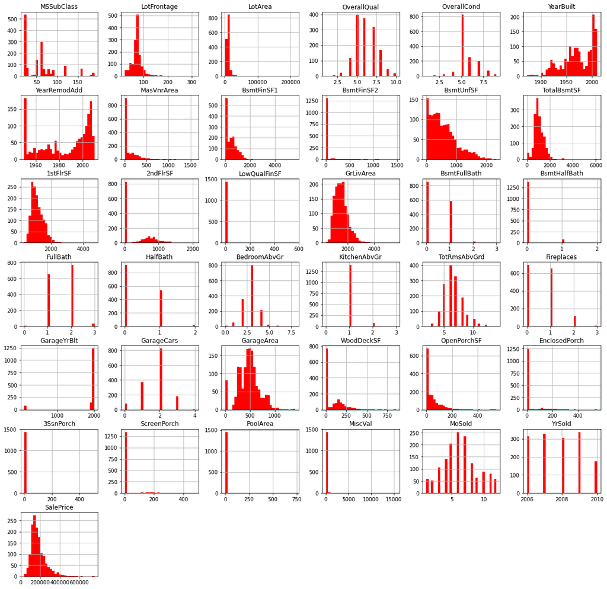

```python
df_train.hist(bins = 30, figsize=(20,20), color = 'r')
plt.show()
```

```python
df_train_regresion = df_train.copy()
```

#### Conversión de las variables categóricas a dummies (variables ficticias)

```python
var_num = df_train_regresion._get_numeric_data().columns.values.tolist()
data_vars = df_train_regresion.columns.values.tolist()
categories  = [v for v in data_vars if v not in var_num]
```

```python
for category in categories:
    cat_dummies = pd.get_dummies(df_train_regresion[category], drop_first=True, prefix=category)
    data_new = df_train_regresion.join(cat_dummies)
    df_train_regresion = data_new
```

```python
df_train_regresion.head(5)
```

|  | MSSubClass | MSZoning | LotFrontage | LotArea | Street | LotShape | LandContour | Utilities | LotConfig | LandSlope | Neighborhood | Condition1 | Condition2 | BldgType | HouseStyle | OverallQual | OverallCond | YearBuilt | YearRemodAdd | RoofStyle | RoofMatl | Exterior1st | Exterior2nd | MasVnrType | MasVnrArea | ExterQual | ExterCond | Foundation | BsmtQual | … |
| --- | --- | --- | --- | --- | --- | --- | --- | --- | --- | --- | --- | --- | --- | --- | --- | --- | --- | --- | --- | --- | --- | --- | --- | --- | --- | --- | --- | --- | --- | --- |
| 0 | 60 | RL | 65.0 | 8450 | Pave | Reg | Lvl | AllPub | Inside | Gtl | CollgCr | Norm | Norm | 1Fam | 2Story | 7 | 5 | 2003 | 2003 | Gable | CompShg | VinylSd | VinylSd | BrkFace | 196.0 | Gd | TA | PConc | Gd | … |
| 1 | 20 | RL | 80.0 | 9600 | Pave | Reg | Lvl | AllPub | FR2 | Gtl | Veenker | Feedr | Norm | 1Fam | 1Story | 6 | 8 | 1976 | 1976 | Gable | CompShg | MetalSd | MetalSd | None | 0.0 | TA | TA | CBlock | Gd | … |
| 2 | 60 | RL | 68.0 | 11250 | Pave | IR1 | Lvl | AllPub | Inside | Gtl | CollgCr | Norm | Norm | 1Fam | 2Story | 7 | 5 | 2001 | 2002 | Gable | CompShg | VinylSd | VinylSd | BrkFace | 162.0 | Gd | TA | PConc | Gd | … |
| 3 | 70 | RL | 60.0 | 9550 | Pave | IR1 | Lvl | AllPub | Corner | Gtl | Crawfor | Norm | Norm | 1Fam | 2Story | 7 | 5 | 1915 | 1970 | Gable | CompShg | Wd Sdng | Wd Shng | None | 0.0 | TA | TA | BrkTil | TA | … |
| 4 | 60 | RL | 84.0 | 14260 | Pave | IR1 | Lvl | AllPub | FR2 | Gtl | NoRidge | Norm | Norm | 1Fam | 2Story | 8 | 5 | 2000 | 2000 | Gable | CompShg | VinylSd | VinylSd | BrkFace | 350.0 | Gd | TA | PConc | Gd | … |

5 rows × 277 columns

#### Se eliminan las columnas de las variables categóricas, elaboramos el modelo con las columnas dummies creadas

```python
data_vars = df_train_regresion.columns.values.tolist()
new_categories  = [v for v in data_vars if v not in categories]
df_train_regresion = df_train_regresion[new_categories]
```

```python
df_train_regresion.head(5)
```

|  | MSSubClass | LotFrontage | LotArea | OverallQual | OverallCond | YearBuilt | YearRemodAdd | MasVnrArea | BsmtFinSF1 | BsmtFinSF2 | BsmtUnfSF | TotalBsmtSF | 1stFlrSF | 2ndFlrSF | LowQualFinSF | GrLivArea | BsmtFullBath | BsmtHalfBath | FullBath | HalfBath | BedroomAbvGr | KitchenAbvGr | TotRmsAbvGrd | Fireplaces | GarageYrBlt | GarageCars | GarageArea | WoodDeckSF | OpenPorchSF | … |
| --- | --- | --- | --- | --- | --- | --- | --- | --- | --- | --- | --- | --- | --- | --- | --- | --- | --- | --- | --- | --- | --- | --- | --- | --- | --- | --- | --- | --- | --- | --- |
| 0 | 60 | 65.0 | 8450 | 7 | 5 | 2003 | 2003 | 196.0 | 706 | 0 | 150 | 856 | 856 | 854 | 0 | 1710 | 1 | 0 | 2 | 1 | 3 | 1 | 8 | 0 | 2003.0 | 2 | 548 | 0 | 61 | … |
| 1 | 20 | 80.0 | 9600 | 6 | 8 | 1976 | 1976 | 0.0 | 978 | 0 | 284 | 1262 | 1262 | 0 | 0 | 1262 | 0 | 1 | 2 | 0 | 3 | 1 | 6 | 1 | 1976.0 | 2 | 460 | 298 | 0 | … |
| 2 | 60 | 68.0 | 11250 | 7 | 5 | 2001 | 2002 | 162.0 | 486 | 0 | 434 | 920 | 920 | 866 | 0 | 1786 | 1 | 0 | 2 | 1 | 3 | 1 | 6 | 1 | 2001.0 | 2 | 608 | 0 | 42 | … |
| 3 | 70 | 60.0 | 9550 | 7 | 5 | 1915 | 1970 | 0.0 | 216 | 0 | 540 | 756 | 961 | 756 | 0 | 1717 | 1 | 0 | 1 | 0 | 3 | 1 | 7 | 1 | 1998.0 | 3 | 642 | 0 | 35 | … |
| 4 | 60 | 84.0 | 14260 | 8 | 5 | 2000 | 2000 | 350.0 | 655 | 0 | 490 | 1145 | 1145 | 1053 | 0 | 2198 | 1 | 0 | 2 | 1 | 4 | 1 | 9 | 1 | 2000.0 | 3 | 836 | 192 | 84 | … |

5 rows × 238 columns

```python
y = df_train_regresion['SalePrice']
```

```python
x = df_train_regresion[[v for v in df_train_regresion.columns.values.tolist() if v not in ["SalePrice"]]]
```

#### Dividir el set de datos en entrenamiento y testing

```python
from sklearn.model_selection import train_test_split
```

```python
x_train, x_test, y_train, y_test = train_test_split(x, y, test_size=0.20, random_state=1)
```

#### Predicción para los bosques aleatorios de regresión

```python
from sklearn.model_selection import KFold
from sklearn.model_selection import cross_val_score
from sklearn.ensemble import RandomForestRegressor
import numpy as np
```

```python
regforest = RandomForestRegressor(n_jobs=2, oob_score=True, n_estimators=10000)
regforest.fit(x_train, y_train)
```

```
RandomForestRegressor(bootstrap=True, ccp_alpha=0.0, criterion='mse',
                      max_depth=None, max_features='auto', max_leaf_nodes=None,
                      max_samples=None, min_impurity_decrease=0.0,
                      min_impurity_split=None, min_samples_leaf=1,
                      min_samples_split=2, min_weight_fraction_leaf=0.0,
                      n_estimators=10000, n_jobs=2, oob_score=True,
                      random_state=None, verbose=0, warm_start=False)
```

```python
preds = regforest.predict(x_test)
```

```python
cv = KFold(n_splits = 10, shuffle=True, random_state=1)
```

**R cuadrado**

```python
scores = cross_val_score(regforest, x_test, y_test, scoring="r2", cv = cv, n_jobs=1)
```

```python
score = np.mean(scores)
print(score)
```

```
0.8554680084636062
```

El coeficiente de determinación es la proporción de la varianza total de la variable explicada por la regresión. El coeficiente de determinación, también llamado R cuadrado, refleja la bondad del ajuste de un modelo a la variable que pretender explicar. Es importante saber que el resultado del coeficiente de determinación oscila entre 0 y 1. Cuanto más cerca de 1 se sitúe su valor, mayor será el ajuste del modelo a la variable que estamos intentando explicar. De forma inversa, cuanto más cerca de cero, menos ajustado estará el modelo y, por tanto, menos fiable será.

### 5. Representación de los resultados

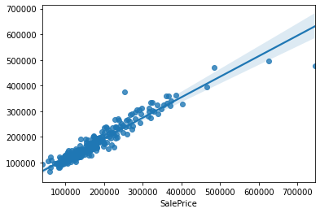

```python
sns.regplot(x=y_test, y=preds)
plt.show()
```

**Conclusión**

Los bosques aleatorios hacen mejor trabajo al predecir ya que promedian los resultados del conjunto de árboles porque tienen en cuenta la decisión de la mayoría por voto, porque funcionan mejor?, es simple porque al ir tomando más y más modelos en consideración se maximiza la reducción de la varianza, donde la varianza queda dividida por raíz de n donde n es el número de árboles que se utilizan y por tanto al tomar una muestra aleatoria simple de valores y al ir creando árboles y arboles al final el hecho de que puedas crear un mal árbol queda compensado por la mejoría en el resto de árboles y el error va quedando dividido al ir metiendo más y más árboles en el bosque , también al tomar una muestra aleatoria simple de variables predictoras para crear el árbol hace que cada árbol sean independiente de los demás, random forest es un algoritmo donde todas las variables de un set de datos son utilizadas óptimamente, en la gran mayoría de algoritmos de machine learning buscamos las variables que sean más importantes para hacer una predicción sin embargo en el caso de un random forest como la selección es aleatoria en las variables al final resulta que las prediciones que lleva a cabo cada árbol se calculan en base a particiones locales, donde algunas de las variables no son importantes en forma global, pero se convierten en significantes en el árbol que se utilizan de modo que así en combinación cada variable saca a relucir todo su potencial, es una técnica donde todo el set de datos se optimiza en forma global y se acaba tomado en cuenta en la generación del bosque esto ayuda a reducir el sesgo que suele aparecer cuando existe la dependencia de un par de las variables predictoras que acaban dominando por encima del resto como sucede en los árboles de decisión y de regresión.

### 6. Resolución del problema. A partir de los resultados obtenidos, ¿cuáles son las conclusiones? ¿Los resultados permiten responder al problema?

El objetivo era construir un modelo que realice una buena predicción a los precios de venta, podemos ver que la predicción utilizando un algoritmo de bosques aleatorios de regresión aplicando la técnica de validación cruzado arrojo muy buenos resultados, Un R cuadrado de 0.85. La variabilidad total de los datos SST (sumatoria de las diferencias al cuadrado de la variable dependiente observada y su media) se pueden descomponer en Explicado SSR (sumatoria de las diferencias al cuadrado del valor predicho y su media) y no explicado SSE (sumatoria de las diferencias al cuadrado entre el valor observado y el pavor predicho), se puede destacar que a menor SSR será mejor será la regresión, en estadística la medida de uso amplio que describa cuan poderosa es una regresión se denomina R cuadrado y equivale a la variabilidad explicada por la regresión SSR dividida entre la variabilidad total SST, es una medida relativa y toma valores entre cero y uno, si un R cuadro es cero significa que la recta de regresión no explica la variabilidad de los datos, mientras q un R cuadrado de uno significaría que el modelo explica toda la variabilidad de los datos, las regresiones que explican toda la variabilidad son raras, lo q usualmente se ve son valores entre 0.2 y 0.9, entonces aquí surge una pregunta de cuanto es un buen r cuadrado, y la respuesta es que no hay una regla definitiva para eso, depende de la complejidad del problema y de cuantas variables están en juego. Para este caso tenemos un R cuadrado de 0.85 esto quiere decir que todas las variables del conjunto de datos explican en un 85% la variabilidad de los datos de la variable SalePrice con lo cual concluimos que es un buen modelo para predecir.